# La existencia de Dios

### Introducción

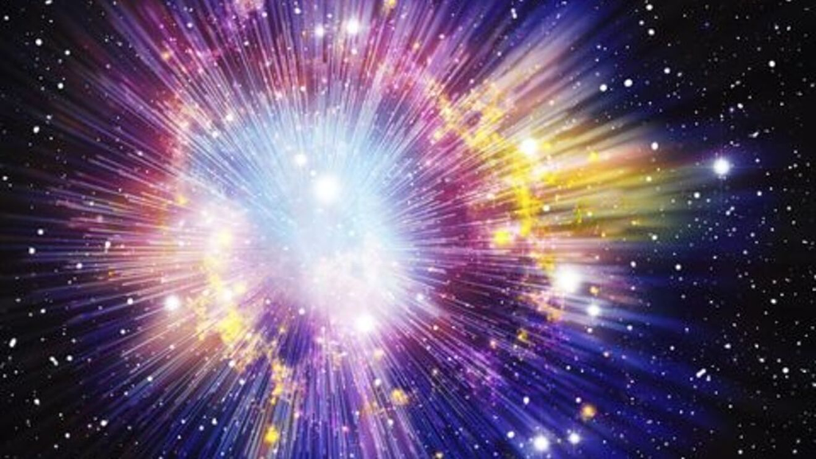

La pregunta sobre la existencia de Dios es una pregunta que se ha hecho siempre el ser humano. Dependiendo la respuesta algunos son **teístas** (creen), otros son **ateos** (no creen) y otros **agnósticos** (creen pero aseguran que no se puede demostrar usando solo argumentos racionales). También parece haber otros que podemos llamar **indiferentes** que han decidido que esto no les interesa y se muestran reacios a plantearse esta pregunta, quizás en el fondo no se atreven a negar a Dios pero quieren vivir como si no existiera.

### Una respuesta racional

En este apartado se reflexiona sobre algunos argumentos que podemos conocer solo con la luz de la razón dejando de lado las creencias religiosas. Es decir: ¿es capaz el hombre, solo con el uso de argumentos de su inteligencia, demostrar que Dios existe?

Santo Tomás de Aquino vivió en la edad media. Fue un hombre santo y profundamente sabio. El diario Clarín, que no tiene nada de religioso, en una enciclopedia sobre los “Hombres que cambiaron el mundo” le dedica todo un fascículo. Santo Tomás estudió profúndamente a Aristóteles y elaboró unas vías para demostrar la existencia de Dios de un modo racional sin meter los conocimientos de la Fe. La 5ta vía, la que tienes que trabajar, es la más sencilla de comprender sin necesidad de conocimientos técnicos filosóficos. Se basa en el principio de “Causalidad” que dice que **todo efecto tiene una causa**. Por ejemplo ves una huella en el campo (el efecto) e inmediatamente piensas que alguien o algo pasó la hizo (causa). Si usas tu experiencia y conocimiento incluso puedes estar seguro que animal la hizo.

#### Actividad

Buscar y escribir la 5ta Vía de Santo Tomás de Aquino para demostrar la existencia de Dios. Esta actividad se termina contando lo que entendiste de esta vía al Profesor en una breve conversación oral.